# Purtell_ProblemSet02

Author

Colin Purtell

## STATS 506 Problem Set 2:

Link to repository: https://github.com/cspurtell/stat506

### Problem 1

#### a.

```r
random_walk1 <- function(n, seed = NULL) {
  if (!is.null(seed)) set.seed(seed)
  position <- 0
  for (i in 1:n) {
    step <- runif(1) #Pulls random value from uniform dist.
    if (step < 0.5) {
      if (runif(1) < 0.05) {
        position <- position + 10
      } else {
        position <- position + 1
      }
    } else {
      if (runif(1) < 0.2) {
        position <- position - 3
      } else {
        position <- position - 1
      }
    }
  }

  return(position)
}

random_walk2 <- function(n, seed = NULL) {
  if (!is.null(seed)) set.seed(seed)
  u <- runif(2 * n)
  dir <- u[seq(1, 2*n, by = 2)] < 0.5    #Direction
  sub <- u[seq(2, 2*n, by = 2)]          #Subtype
  steps <- ifelse(dir,
                  ifelse(sub < 0.05, 10, 1),
                  ifelse(sub < 0.2, -3, -1))

  sum(steps)
}

random_walk3 <- function(n, seed = NULL) {
  if (!is.null(seed)) set.seed(seed)
  steps <- sapply(1:n, function(i) {
    if (runif(1) < 0.5) {
      if (runif(1) < 0.05) 10 else 1
    } else {
      if (runif(1) < 0.2) -3 else -1
    }
  })

  sum(steps)
}
```

```r
random_walk1(10)
```

```
[1] -4
```

```r
random_walk2(10)
```

```
[1] 0
```

```r
random_walk3(10)
```

```
[1] 2
```

```r
random_walk1(1000)
```

```
[1] 49
```

```r
random_walk2(1000)
```

```
[1] -5
```

```r
random_walk3(1000)
```

```
[1] 90
```

#### b.

```r
random_walk1(10, seed=42)
```

```
[1] -6
```

```r
random_walk2(10, seed=42)
```

```
[1] -6
```

```r
random_walk3(10, seed=42)
```

```
[1] -6
```

```r
random_walk1(1000, seed=42)
```

```
[1] 54
```

```r
random_walk2(1000, seed=42)
```

```
[1] 54
```

```r
random_walk3(1000, seed=42)
```

```
[1] 54
```

#### c.

For low input (1,000):

```r
library(microbenchmark)
microbenchmark(
  loop = random_walk1(1000),
  vectorized = random_walk2(1000),
  apply = random_walk3(1000),
  times = 100
)
```

```
Unit: microseconds
       expr    min     lq     mean  median      uq    max neval
       loop 2395.2 2421.3 2486.264 2435.50 2456.50 4631.0   100
 vectorized  253.4  274.3  307.086  297.00  329.75  454.1   100
      apply 3653.4 3684.2 3832.997 3713.05 3763.60 6637.8   100
```

For large input (100,000):

```r
microbenchmark(
  loop = random_walk1(100000),
  vectorized = random_walk2(100000),
  apply = random_walk3(100000),
  times = 10
)
```

```
Unit: milliseconds
       expr      min       lq      mean   median       uq      max neval
       loop 246.6465 253.6844 267.62842 266.9690 282.0429 292.0051    10
 vectorized  14.8800  17.6790  18.77052  19.3671  19.5538  22.8222    10
      apply 394.2072 417.4442 436.66939 435.8935 458.7984 478.5057    10
```

#### d.

```r
simulate_prob <- function(n, trials = 10000) {
  results <- replicate(trials, random_walk1(n) == 0)
  successes <- sum(results)   # count how many ended at 0
  prop.test(successes, trials)
}
```

For n = 10, we have:

```r
simulate_prob(10)
```

```
    1-sample proportions test with continuity correction

data:  successes out of trials, null probability 0.5
X-squared = 5254.8, df = 1, p-value < 2.2e-16
alternative hypothesis: true p is not equal to 0.5
95 percent confidence interval:
 0.1308405 0.1444400
sample estimates:
     p
0.1375
```

Therefore, the probability that a walk ends at 0 after 10 steps is 13.75%

For n = 100, we have:

```r
simulate_prob(100)
```

```
    1-sample proportions test with continuity correction

data:  successes out of trials, null probability 0.5
X-squared = 9318, df = 1, p-value < 2.2e-16
alternative hypothesis: true p is not equal to 0.5
95 percent confidence interval:
 0.01487724 0.02010071
sample estimates:
     p
0.0173
```

Therefore, the probability that a walk ends at 0 after 100 steps is 1.73%

For n = 1,000, we have:

```r
simulate_prob(1000)
```

```
    1-sample proportions test with continuity correction

data:  successes out of trials, null probability 0.5
X-squared = 9735.8, df = 1, p-value < 2.2e-16
alternative hypothesis: true p is not equal to 0.5
95 percent confidence interval:
 0.005147435 0.008443346
sample estimates:
     p
0.0066
```

Therefore, the probability that a walk ends at 0 after 1,000 steps is 0.66%

### Problem 2

```r
simulate_daily_cars <- function(trials = 100000, seed = 1) {
  if (!is.null(seed)) set.seed(seed)

  totals <- rowSums(cbind(
    replicate(8, rpois(trials, 1)),           # midnight-7AM
    rnorm(trials, 60, sqrt(12)),              # 8AM
    replicate(8, rpois(trials, 8)),           # 9AM-4PM
    rnorm(trials, 60, sqrt(12)),              # 5PM
    replicate(6, rpois(trials, 12))           # 6PM-11PM
  ))

  mean_daily <- mean(totals)
  se_mean <- sd(totals) / sqrt(trials)
  ci95 <- mean_daily + c(-1,1) * qnorm(0.975) * se_mean

  list(mean_daily = mean_daily, se_mean = se_mean, ci95_mean = ci95)
}

simulate_daily_cars()
```

```
$mean_daily
[1] 263.9983

$se_mean
[1] 0.0409791

$ci95_mean
[1] 263.9180 264.0787
```

According to the results, the average number of cars that pass the specified intersection per day is about 264.

### Problem 3

```r
youtube <- read.csv('https://raw.githubusercontent.com/rfordatascience/tidytuesday/master/data/2021/2021-03-02/youtube.csv')
```

#### a.

```r
youtube_sub <- subset(youtube, select = -c(brand, superbowl_ads_dot_com_url, youtube_url, id, etag, published_at, title, description, thumbnail,
  channel_title)
)

dim(youtube_sub)
```

```
[1] 247  15
```

#### b.

I. View counts

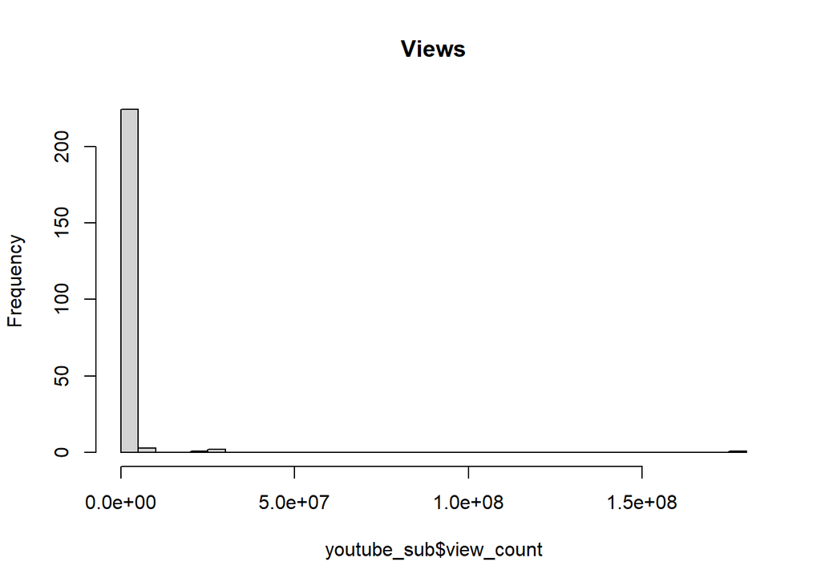

```r
hist(youtube_sub$view_count, main="Views", breaks=30)
```

This seems viable enough, but will need a log transformation:

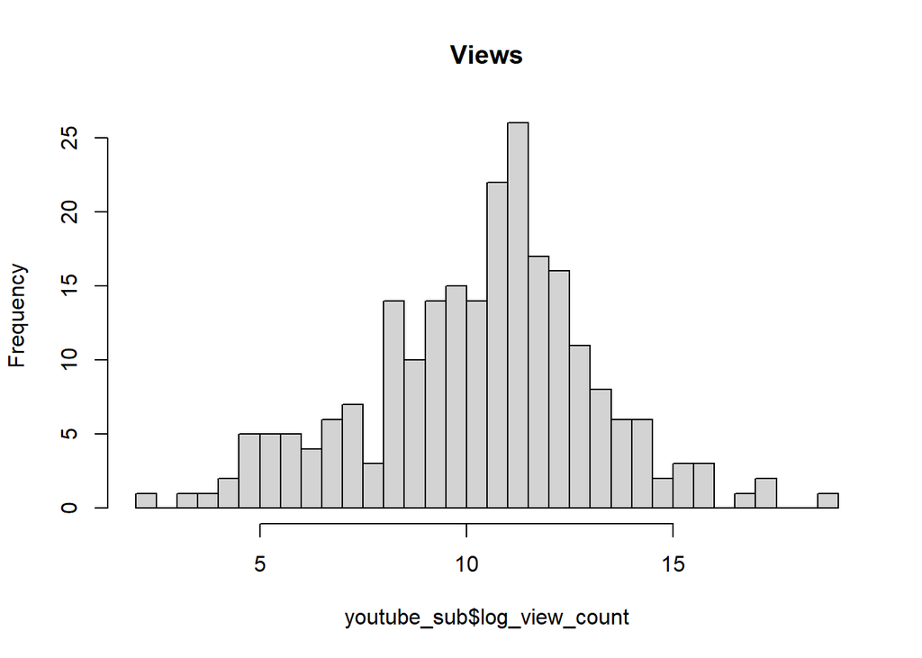

```r
youtube_sub$log_view_count <- log1p(youtube_sub$view_count)
hist(youtube_sub$log_view_count, main="Views", breaks=30)
```

With the transformation applied, we can see that view count is now appropriate to use

II. Like counts

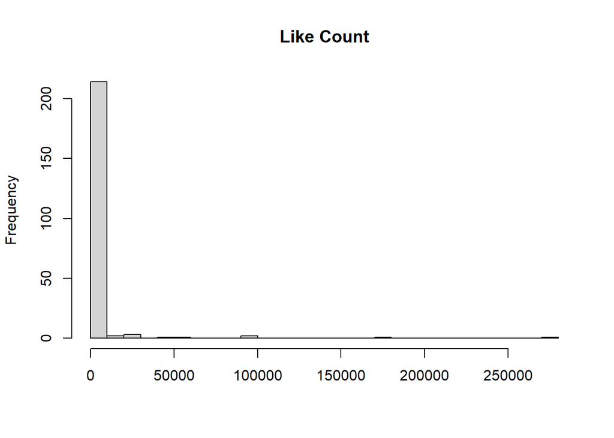

```r
hist(youtube_sub$like_count, main="Like Count", xlab="", breaks=30)
```

This seems viable enough, but will need a log transformation:

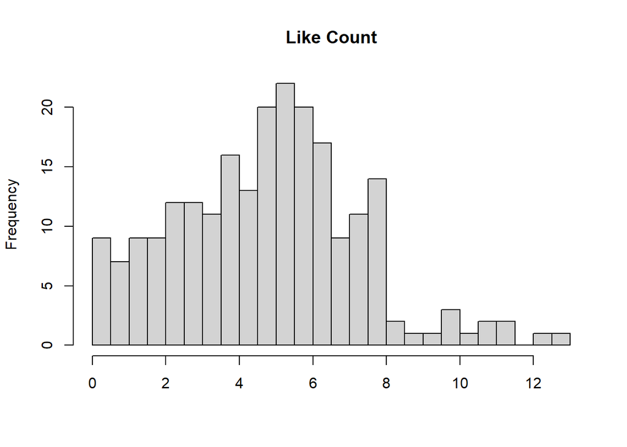

```r
youtube_sub$log_like_count <- log1p(youtube_sub$like_count)
hist(youtube_sub$log_like_count, main="Like Count", xlab="", breaks = 30)
```

With the transformation applied, we can see that like count is now appropriate to use

III. Dislike count

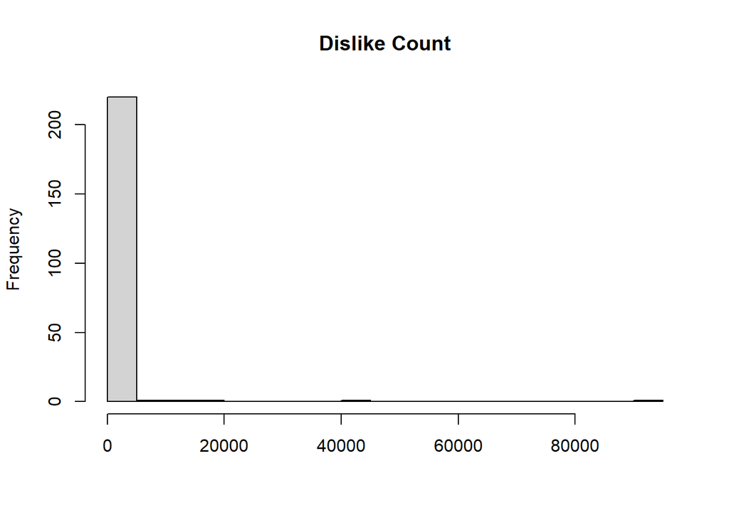

```r
hist(youtube_sub$dislike_count, main="Dislike Count", xlab="", breaks=30)
```

This seems iffy, but we can try a log transformation like the previous variables:

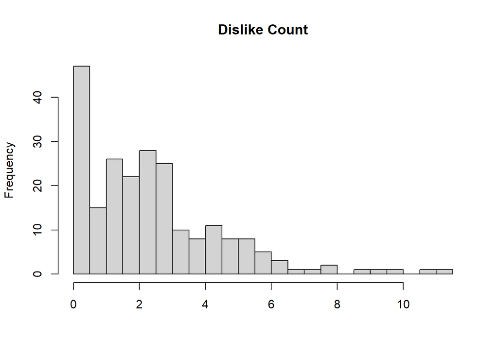

```r
youtube_sub$log_dislike_count <- log1p(youtube_sub$dislike_count)
hist(youtube_sub$log_dislike_count, main="Dislike Count", xlab="", breaks=30)
```

With the transformation applied, we can see that dislike count is now appropriate to use

IV. Favorite Count

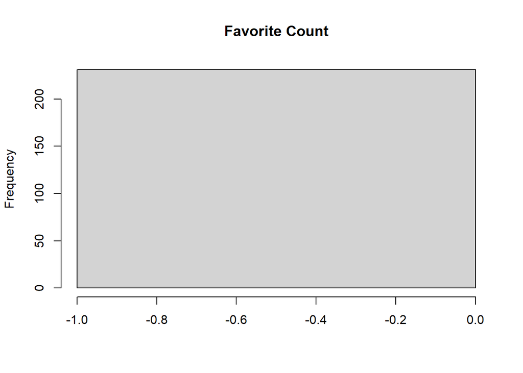

```r
hist(youtube_sub$favorite_count, main="Favorite Count", xlab="", breaks=30)
```

This variable does not seem appropriate to use for a linear model

V. Comment count

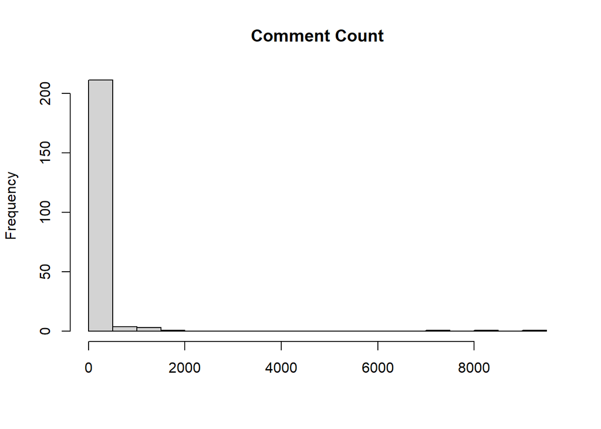

```r
hist(youtube_sub$comment_count, main="Comment Count", xlab="", breaks=30)
```

This seems viable enough, but will need a log transformation:

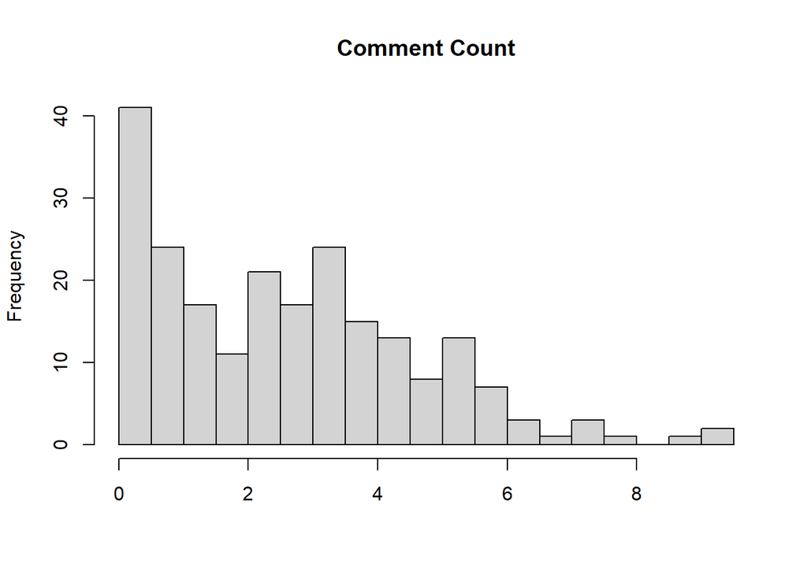

```r
youtube_sub$log_comment_count <- log1p(youtube_sub$comment_count)
hist(youtube_sub$log_comment_count, main="Comment Count", xlab="", breaks=30)
```

With the transformation applied, we can see that dislike count is now appropriate to use

#### c.

I. View counts

```r
model_views <- lm(log_view_count ~ funny + show_product_quickly + patriotic +
                    celebrity + danger + animals + use_sex + year,
                  data = youtube_sub)
summary(model_views)
```

```
Call:
lm(formula = log_view_count ~ funny + show_product_quickly +
    patriotic + celebrity + danger + animals + use_sex + year,
    data = youtube_sub)

Residuals:
    Min      1Q  Median      3Q     Max
-7.7742 -1.6152  0.1311  1.7036  8.4481

Coefficients:
                          Estimate Std. Error t value Pr(>|t|)
(Intercept)              -31.55016   71.00538  -0.444    0.657
funnyTRUE                  0.56492    0.46702   1.210    0.228
show_product_quicklyTRUE   0.21089    0.40530   0.520    0.603
patrioticTRUE              0.50699    0.53811   0.942    0.347
celebrityTRUE              0.03548    0.42228   0.084    0.933
dangerTRUE                 0.63131    0.41812   1.510    0.132
animalsTRUE               -0.31002    0.39348  -0.788    0.432
use_sexTRUE               -0.38671    0.44782  -0.864    0.389
year                       0.02053    0.03531   0.582    0.561

Residual standard error: 2.787 on 222 degrees of freedom
  (16 observations deleted due to missingness)
Multiple R-squared:  0.02694,   Adjusted R-squared:  -0.008122
F-statistic: 0.7684 on 8 and 222 DF,  p-value: 0.631
```

II. Like counts

```r
model_likes <- lm(log_like_count ~ funny + show_product_quickly + patriotic +
                    celebrity + danger + animals + use_sex + year,
                  data = youtube_sub)
summary(model_likes)
```

```
Call:
lm(formula = log_like_count ~ funny + show_product_quickly +
    patriotic + celebrity + danger + animals + use_sex + year,
    data = youtube_sub)

Residuals:
    Min      1Q  Median      3Q     Max
-5.2860 -1.6333  0.0868  1.4911  7.7431

Coefficients:
                           Estimate Std. Error t value Pr(>|t|)
(Intercept)              -150.51357   63.45723  -2.372   0.0186 *
funnyTRUE                   0.47476    0.41816   1.135   0.2575
show_product_quicklyTRUE    0.20017    0.36391   0.550   0.5828
patrioticTRUE               0.80689    0.49791   1.621   0.1066
celebrityTRUE               0.41283    0.38212   1.080   0.2812
dangerTRUE                  0.63895    0.37350   1.711   0.0886 .
animalsTRUE                -0.05944    0.35298  -0.168   0.8664
use_sexTRUE                -0.42952    0.40064  -1.072   0.2849
year                        0.07685    0.03155   2.436   0.0157 *
---
Signif. codes:  0 '***' 0.001 '**' 0.01 '*' 0.05 '.' 0.1 ' ' 1

Residual standard error: 2.467 on 216 degrees of freedom
  (22 observations deleted due to missingness)
Multiple R-squared:  0.07313,   Adjusted R-squared:  0.03881
F-statistic:  2.13 on 8 and 216 DF,  p-value: 0.0342
```

According to the summary output, only year is a significant predictor at conventional thresholds such as 0.05. The overall model fit is weak, and the coefficients suggest a mostly positive relationship. However, the F-statistic and p-value indicate that the inputs as a set have some predictive value.

III. Dislike counts

```r
model_dislikes <- lm(log_dislike_count ~ funny + show_product_quickly + patriotic +
                    celebrity + danger + animals + use_sex + year,
                  data = youtube_sub)
summary(model_dislikes)
```

```
Call:
lm(formula = log_dislike_count ~ funny + show_product_quickly +
    patriotic + celebrity + danger + animals + use_sex + year,
    data = youtube_sub)

Residuals:
    Min      1Q  Median      3Q     Max
-4.0292 -1.3299 -0.3192  0.8986  8.7219

Coefficients:
                           Estimate Std. Error t value Pr(>|t|)
(Intercept)              -183.06813   53.34768  -3.432 0.000719 ***
funnyTRUE                   0.25949    0.35154   0.738 0.461224
show_product_quicklyTRUE    0.27511    0.30593   0.899 0.369515
patrioticTRUE               0.81407    0.41859   1.945 0.053095 .
celebrityTRUE              -0.20214    0.32125  -0.629 0.529852
dangerTRUE                  0.22184    0.31400   0.707 0.480630
animalsTRUE                -0.21192    0.29675  -0.714 0.475911
use_sexTRUE                -0.32980    0.33681  -0.979 0.328583
year                        0.09207    0.02653   3.471 0.000626 ***
---
Signif. codes:  0 '***' 0.001 '**' 0.01 '*' 0.05 '.' 0.1 ' ' 1

Residual standard error: 2.074 on 216 degrees of freedom
  (22 observations deleted due to missingness)
Multiple R-squared:  0.09753,   Adjusted R-squared:  0.06411
F-statistic: 2.918 on 8 and 216 DF,  p-value: 0.004115
```

According to the summary output, only year is a significant predictor at conventional thresholds such as 0.05, although “patriotic” comes very close. The overall model fit is weak, and the coefficients suggest a mixed relationship with both positive and negative slopes. However, the F-statistic and p-value indicate that the inputs as a set have some predictive value.

IV. Comment counts

```r
model_comments <- lm(log_comment_count ~ funny + show_product_quickly + patriotic +
                       celebrity + danger + animals + use_sex + year,
                     data = youtube_sub)
summary(model_comments)
```

```
Call:
lm(formula = log_comment_count ~ funny + show_product_quickly +
    patriotic + celebrity + danger + animals + use_sex + year,
    data = youtube_sub)

Residuals:
    Min      1Q  Median      3Q     Max
-4.1372 -1.4665 -0.1427  1.4061  5.8468

Coefficients:
                          Estimate Std. Error t value Pr(>|t|)
(Intercept)              -99.09835   52.92351  -1.872   0.0625 .
funnyTRUE                  0.21954    0.34528   0.636   0.5256
show_product_quicklyTRUE   0.40939    0.30229   1.354   0.1771
patrioticTRUE              0.66698    0.39902   1.672   0.0961 .
celebrityTRUE              0.29767    0.31541   0.944   0.3464
dangerTRUE                 0.17784    0.31069   0.572   0.5677
animalsTRUE               -0.26802    0.29347  -0.913   0.3621
use_sexTRUE               -0.39323    0.33163  -1.186   0.2370
year                       0.05034    0.02632   1.913   0.0571 .
---
Signif. codes:  0 '***' 0.001 '**' 0.01 '*' 0.05 '.' 0.1 ' ' 1

Residual standard error: 2.039 on 213 degrees of freedom
  (25 observations deleted due to missingness)
Multiple R-squared:  0.06535,   Adjusted R-squared:  0.03025
F-statistic: 1.862 on 8 and 213 DF,  p-value: 0.06748
```

According to the summary output, none of the predictors are significant at conventional thresholds such as 0.05, although year comes close. The overall model fit is weak, and the coefficients suggest a mostly positive relationship (were there to be one). The F-statistic and p-value indicate that the inputs as a set do not have any significant predictive power.

#### d.

```r
y <- youtube_sub$log_view_count
X <- model.matrix(~ funny + show_product_quickly + patriotic +
                    celebrity + danger + animals + use_sex + year,
                  data = youtube_sub)
complete_idx <- complete.cases(X, y)
X <- X[complete_idx, ]
y <- y[complete_idx]

beta_hat <- solve(crossprod(X)) %*% crossprod(X, y)
beta_hat
```

```
                                 [,1]
(Intercept)              -31.55015804
funnyTRUE                  0.56492445
show_product_quicklyTRUE   0.21088918
patrioticTRUE              0.50699051
celebrityTRUE              0.03547862
dangerTRUE                 0.63131085
animalsTRUE               -0.31001838
use_sexTRUE               -0.38670726
year                       0.02053399
```

When comparing these results to the coefficients found using lm(), we find identical values.

### Resources Used:

R documentation for model.matrix(), ChatGPT for debugging purposes